# index

***What is the relationship between the components of the weather and their impact on each other?*** **By Ng Ye Kai**

*Questions to answer:* What is the impact of the monsoon/other seasons on monthly humidity and temperature? What is the impact of the monsoon/other seasons on wet bulb temperature what is the impact of higher average monthly temperatures on wet bulb temperature? what is the relationship between relative humidity and wet bulb temperature? Considering: Air quality records (PM2.5) + relationship with rainfall/humidity Rainfall - temperature - humidity relationship WBGT display over the years rainfall over the years Air quality over the years

*Resources:* Wet Bulb Temperature - Hourly; https://beta.data.gov.sg/datasets/d_f222c70a7c00c5a5a9d4ec432d67f6e8/view Recorded by placing a piece of wet cloth over a temperature recorder and measuring temperature after

Relative Humidity - Monthly Mean; https://beta.data.gov.sg/datasets/d_e3b1111a26b2aefef4f386c068d4ca5d/view Recorded by calculating the difference between WBT and normal temperature

Surface Air Temperature - Monthly Mean; https://beta.data.gov.sg/datasets/d_755290a24afe70c8f9e8bcbf9f251573/view Recorded by a temperature recorder not under direct sunlight, taking the monthly mean of temperatures

Rainfall - Monthly Total; https://beta.data.gov.sg/datasets/d_b16d06b83473fdfcc92ed9d37b66ba58/view Recorded by collecting rainfall level at the station and adding each day into a month

Historical PSI - 24-hr; https://beta.data.gov.sg/datasets/d_b4cf557f8750260d229c49fd768e11ed/view - ERROR in formatting at record for 4/4/2016 00:00, had to manually reformat. Record of historical PSI levels

Surface Air Temperature - Monthly Mean Daily Minimum; https://beta.data.gov.sg/datasets/d_c92edf841336f03ab51c6693ac8d33ad/view Temperature mean daily min by month

Surface Air Temperature - Monthly Mean Daily Maximum; https://beta.data.gov.sg/datasets/d_b0fb69de67054d6d741bea78274ecc2a/view Temperature mean daily max by month

Pre processing base data plots with yearly averages: (also to get and arrange data; eg converting all datetime formats to timestamp for even time formatting)

```python
# Data Processing
# Import modules
import numpy as np
import matplotlib.pyplot as plt
from datetime import datetime, timedelta


# Functions for turning date formats to timestamps
date_format = '%d/%m/%Y %H:%M'
def convert_to_timestamp(value):
    # Attempt to parse and convert to timestamp
    date_object = datetime.strptime(value, date_format)
    return int(date_object.timestamp())

date_format1 = '%Y-%m'
def convert_to_timestamp1(value):
    # Attempt to parse and convert to timestamp
    date_object = datetime.strptime(value, date_format1)
    return int(date_object.timestamp())

date_format2 = '%Y-%m-%d/%H'
def convert_to_timestamp2(value,value1):
    # Attempt to parse and convert to timestamp
    if value1 == '24':
        # If hour is 24, set hour to 0 and add one day to the date part
        date_object = datetime.strptime(value, '%Y-%m-%d') + timedelta(days=1)
    else:
        timestamp = value + '/' + value1
        date_object = datetime.strptime(timestamp, date_format2)
    return int(date_object.timestamp())

date_format3 = '%Y'
def convert_to_timestamp3(value):
    # Attempt to parse and convert to timestamp
    date_object = datetime.strptime(value, date_format3)
    return int(date_object.timestamp())



# Get and read file data
file = 'datasets/Historical1hrPM2.5.csv'
data = np.genfromtxt(file,delimiter=',',dtype=['U50','i8','i8','i8','i8','i8'],names=True)
# could also use specific cols like:
# data = np.genfromtxt(file,delimiter=',',dtype=['U50','i8'],usecols=(0,1),names=True)

# Iterate through the array and update date strings to timestamps
for i in range(len(data)):
    temp = list(data[i])
    temp[0] = convert_to_timestamp(temp[0])
    data[i] = tuple(temp)
# Changing array data types
data = np.array(data,dtype=[('timestamp','<i8'), ('north', 'i4'), ('south', 'i4'), ('east', 'i4'), ('west', 'i4'), ('central', 'i4')])

# Convert Unix timestamps to datetime objects
timestamps = np.array([datetime.fromtimestamp(ts) for ts in data['timestamp']])
# Extract the year from each datetime object
years = np.array([ts.year for ts in timestamps])
# Group the values by year and calculate the average, as well as convert the year back to timestamp
unique_years = np.unique(years)
average_values = np.array([np.mean(((data['north']+data['south']+data['east']+data['west']+data['central'])/5)[years == year]) for year in unique_years])
for i in range(len(unique_years)):
    unique_years[i] = convert_to_timestamp3(str(unique_years[i]))

# Plot table and adjust x value representation
plt.figure(figsize=(12, 6))
plt.grid(True)
xlabels = ('2014', '2016', '2018','2020', '2022','2024')
xticks = [1388509200,1451581200,1514739600,1577811600,1640970000,1704042000]
plt.plot(data['timestamp'],(data['north']+data['south']+data['east']+data['west']+data['central'])/5, label='Raw Data', linewidth=0.2)
plt.plot(unique_years, average_values, marker='o', linestyle='-', label='Average Yearly Total', color='r')
plt.xticks(xticks,xlabels)

# Table title, etc
plt.title('Historical PM2.5')
plt.xlabel('1/1 of each year')
plt.ylabel('Average Islandwide PM2.5 level')
plt.show()



# Get and read file data
file = 'datasets/Historical24hrPSI.csv'
data1 = np.genfromtxt(file,delimiter=',',dtype=['U50','i8','i8','i8','i8','i8'],names=True)

# Iterate through the array and update date strings to timestamps
for i in range(len(data1)):
    temp = list(data1[i])
    temp[0] = convert_to_timestamp(temp[0])
    data1[i] = tuple(temp)
# Changing array data types
data1 = np.array(data1,dtype=[('timestamp','<i8'), ('north', 'i4'), ('south', 'i4'), ('east', 'i4'), ('west', 'i4'), ('central', 'i4')])

# Convert Unix timestamps to datetime objects
timestamps = np.array([datetime.fromtimestamp(ts) for ts in data1['timestamp']])
# Extract the year from each datetime object
years = np.array([ts.year for ts in timestamps])
# Group the values by year and calculate the average, as well as convert the year back to timestamp
unique_years = np.unique(years)
average_values = np.array([np.mean(((data1['north']+data1['south']+data1['east']+data1['west']+data1['central'])/5)[years == year]) for year in unique_years])
for i in range(len(unique_years)):
    unique_years[i] = convert_to_timestamp3(str(unique_years[i]))

# Plot table and adjust x value representation
plt.figure(figsize=(12, 6))
plt.grid(True)
xlabels = ('2014', '2016', '2018','2020', '2022','2024')
xticks = [1388509200,1451581200,1514739600,1577811600,1640970000,1704042000]
plt.plot(data1['timestamp'],(data1['north']+data1['south']+data1['east']+data1['west']+data1['central'])/5, label='Raw Data', linewidth=0.9)
plt.plot(unique_years, average_values, marker='o', linestyle='-', label='Average Yearly Total', color='r')
plt.xticks(xticks,xlabels)
plt.legend()
# Table title, etc
plt.title('Historical PSI Levels')
plt.xlabel('1/1 of each year')
plt.ylabel('Average Islandwide PSI level')
plt.show()



# Get and read file data
file = 'datasets/RainfallMonthlyTotal.csv'
data2 = np.genfromtxt(file,delimiter=',',dtype=['U50','U50'],names=True)

# Iterate through the array and update date strings to timestamps
for i in range(len(data2)):
    temp = list(data2[i])
    temp[0] = convert_to_timestamp1(temp[0])
    data2[i] = tuple(temp)
# Changing array data types
data2 = np.array(data2,dtype=[('timestamp','<i8'), ('total_rainfall', float)])

# Convert Unix timestamps to datetime objects
timestamps = np.array([datetime.fromtimestamp(ts) for ts in data2['timestamp']])
# Extract the year from each datetime object
years = np.array([ts.year for ts in timestamps])
# Group the values by year and calculate the average, as well as convert the year back to timestamp
unique_years = np.unique(years)
average_values = np.array([np.mean(data2['total_rainfall'][years == year]) for year in unique_years])
for i in range(len(unique_years)):
    unique_years[i] = convert_to_timestamp3(str(unique_years[i]))
# Plot the average yearly
plt.figure(figsize=(12, 6))
plt.plot(unique_years, average_values, marker='o', linestyle='-', label='Average Yearly', color='r')
plt.grid(True)
```

```python
# Plot table and adjust x value representation
xlabels = ('1982', '1988', '1994','2000', '2006','2012','2018','2024')
xticks = [378691200,567993600,757382400,946684800,1136073600,1325376000,1514764800,1704067200]
plt.scatter(data2['timestamp'],data2['total_rainfall'], label='Raw Data')
plt.xticks(xticks,xlabels)
plt.legend()
# Table title, etc
plt.title('Historical Rainfall Levels')
plt.xlabel('1/1 of each year')
plt.ylabel('Total Rainfall Amount')
plt.show()



# Get and read file data
file = 'datasets/RelativeHumidityMonthlyMean.csv'
data3 = np.genfromtxt(file,delimiter=',',dtype=['U50','U50'],names=True)

# Iterate through the array and update date strings to timestamps
for i in range(len(data3)):
    temp = list(data3[i])
    temp[0] = convert_to_timestamp1(temp[0])
    data3[i] = tuple(temp)
# Changing array data types
data3 = np.array(data3,dtype=[('timestamp','<i8'), ('mean_rh', float)])

# Convert Unix timestamps to datetime objects
timestamps = np.array([datetime.fromtimestamp(ts) for ts in data3['timestamp']])
# Extract the year from each datetime object
years = np.array([ts.year for ts in timestamps])
# Group the values by year and calculate the average, as well as convert the year back to timestamp
unique_years = np.unique(years)
average_values = np.array([np.mean(data3['mean_rh'][years == year]) for year in unique_years])
for i in range(len(unique_years)):
    unique_years[i] = convert_to_timestamp3(str(unique_years[i]))
# Plot the average yearly
plt.figure(figsize=(12, 6))
plt.plot(unique_years, average_values, marker='o', linestyle='-', label='Average Yearly', color='r')
plt.grid(True)

# Plot table and adjust x value representation
xlabels = ('1982', '1988', '1994','2000', '2006','2012','2018','2024')
xticks = [378691200,567993600,757382400,946684800,1136073600,1325376000,1514764800,1704067200]
plt.scatter(data3['timestamp'],data3['mean_rh'], label='Raw Data')
plt.xticks(xticks,xlabels)
plt.legend()
# Table title, etc
plt.title('Historical Mean Humidity Levels')
plt.xlabel('1/1 of each year')
plt.ylabel('Monthly Mean Humidity Level')
plt.show()



# Get and read file data
file = 'datasets/SurfaceAirTemperatureMonthlyMean.csv'
data4 = np.genfromtxt(file,delimiter=',',dtype=['U50','U50'],names=True)

# Iterate through the array and update date strings to timestamps
for i in range(len(data4)):
    temp = list(data4[i])
    temp[0] = convert_to_timestamp1(temp[0])
    data4[i] = tuple(temp)
# Changing array data types
data4 = np.array(data4,dtype=[('timestamp','<i8'), ('mean_temp', float)])

# Convert Unix timestamps to datetime objects
timestamps = np.array([datetime.fromtimestamp(ts) for ts in data4['timestamp']])
# Extract the year from each datetime object
years = np.array([ts.year for ts in timestamps])
# Group the values by year and calculate the average, as well as convert the year back to timestamp
unique_years = np.unique(years)
average_values = np.array([np.mean(data4['mean_temp'][years == year]) for year in unique_years])
for i in range(len(unique_years)):
    unique_years[i] = convert_to_timestamp3(str(unique_years[i]))
# Plot the average yearly
plt.figure(figsize=(12, 6))
plt.plot(unique_years, average_values, marker='o', linestyle='-', label='Average Yearly', color='r')
plt.grid(True)

# Plot table and adjust x value representation
xlabels = ('1982', '1988', '1994','2000', '2006','2012','2018','2024')
xticks = [378691200,567993600,757382400,946684800,1136073600,1325376000,1514764800,1704067200]
plt.scatter(data4['timestamp'],data4['mean_temp'], label='Raw Data')
plt.xticks(xticks,xlabels)
plt.legend()
# Table title, etc
plt.title('Historical Mean Temperature Levels')
plt.xlabel('1/1 of each year')
plt.ylabel('Monthly Mean Temperature Level')
plt.show()



# Get and read file data
file = 'datasets/WetBulbTemperatureHourly.csv'
data5 = np.genfromtxt(file,delimiter=',',dtype=['U50','U50','U50'],names=True)

# Iterate through the array and update date strings to timestamps
for i in range(len(data5)):
    temp = list(data5[i])
    temp[0] = convert_to_timestamp2(temp[0],temp[1])
    data5[i] = tuple(temp)

# Changing array data types
data5 = np.array(data5,dtype=[('timestamp','<i8'), ('extra', '<i8'), ('wbt_temp', float)])

# Plot table and adjust x value representation
xlabels = ('1982', '1988', '1994','2000', '2006','2012','2018','2024')
xticks = [378691200,567993600,757382400,946684800,1136073600,1325376000,1514764800,1704067200]
fig = plt.figure(figsize=(30,6))
ax = fig.add_subplot()
ax.scatter(data5['timestamp'],data5['wbt_temp'])
ax.set_xticks(xticks,xlabels)
# remove plot borders
ax.spines[:].set_visible(False) #use open slice to address all spines
# add gridlines
ax.grid(visible=True)
# Table title, etc
ax.set_title('Historical Wet Bulb Temperature Levels',fontsize=28, fontweight='bold')
ax.set_xlabel('1/1 of each year',fontsize=20, fontweight='bold')
ax.set_ylabel('Wet Bulb Temperature Level',fontsize=20, fontweight='bold')
plt.show()



# Get and read file data
file = 'datasets/SurfaceAirTemperatureMonthlyMeanDailyMinimum.csv'
data4_min = np.genfromtxt(file,delimiter=',',dtype=['U50','U50'],names=True)

# Iterate through the array and update date strings to timestamps
for i in range(len(data4_min)):
    temp = list(data4_min[i])
    temp[0] = convert_to_timestamp1(temp[0])
    data4_min[i] = tuple(temp)
# Changing array data types
data4_min = np.array(data4_min,dtype=[('timestamp','<i8'), ('mean_daily_min', float)])

# Convert Unix timestamps to datetime objects
timestamps = np.array([datetime.fromtimestamp(ts) for ts in data4_min['timestamp']])
# Extract the year from each datetime object
years = np.array([ts.year for ts in timestamps])
# Group the values by year and calculate the average, as well as convert the year back to timestamp
unique_years = np.unique(years)
average_values = np.array([np.mean(data4_min['mean_daily_min'][years == year]) for year in unique_years])
for i in range(len(unique_years)):
    unique_years[i] = convert_to_timestamp3(str(unique_years[i]))
# Plot the average yearly
plt.figure(figsize=(12, 6))
plt.plot(unique_years, average_values, marker='o', linestyle='-', label='Average Yearly', color='r')
plt.grid(True)
```

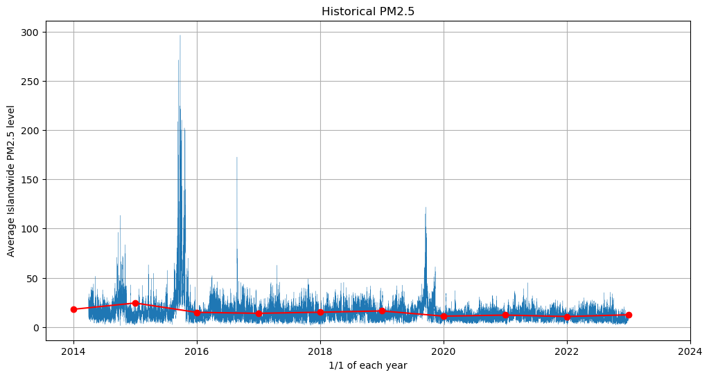

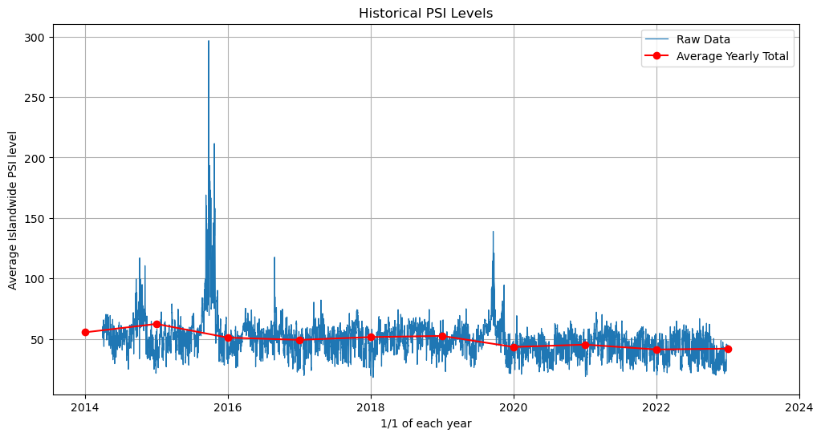

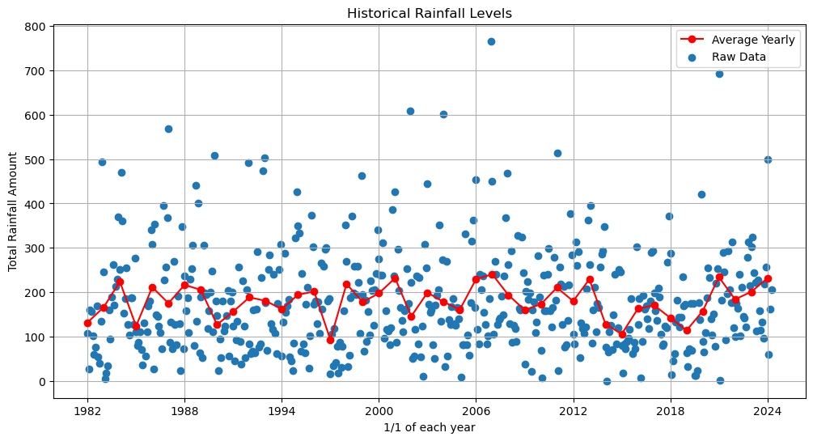

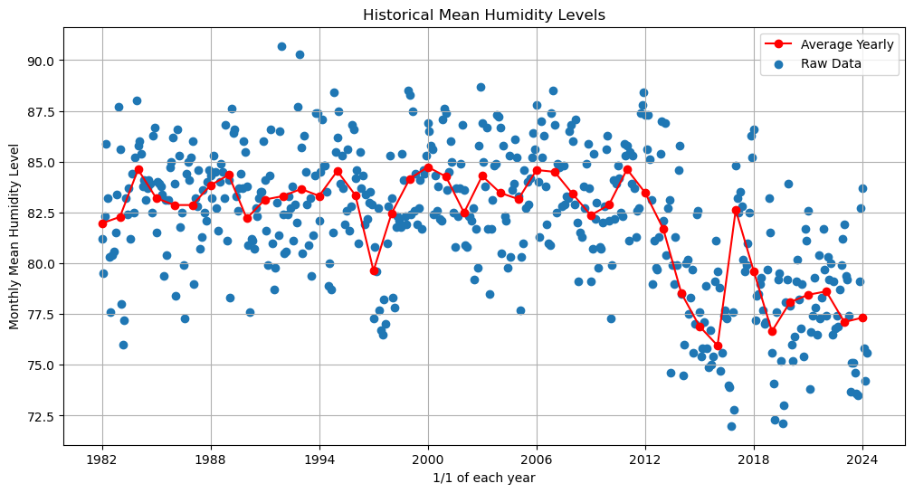

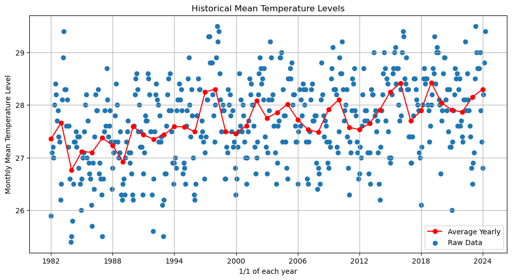

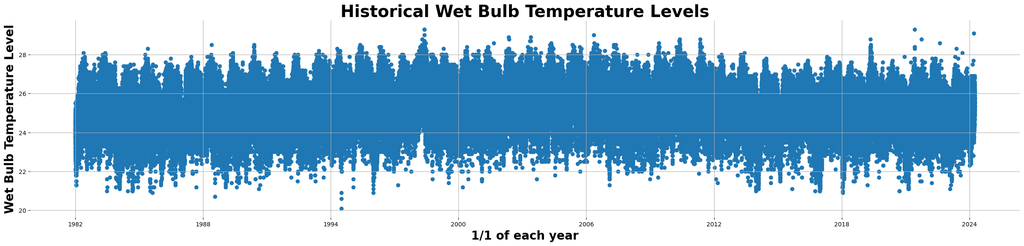

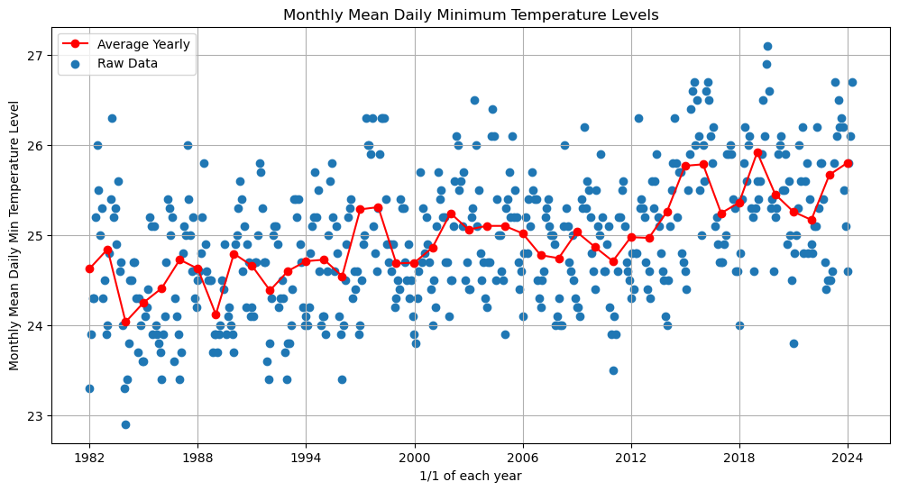

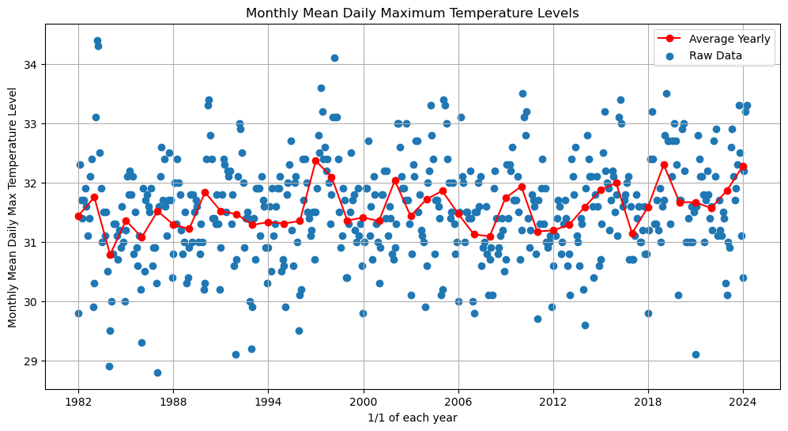

```python
# Plot table and adjust x value representation
xlabels = ('1982', '1988', '1994','2000', '2006','2012','2018','2024')
xticks = [378691200,567993600,757382400,946684800,1136073600,1325376000,1514764800,1704067200]
plt.scatter(data4_min['timestamp'],data4_min['mean_daily_min'], label='Raw Data')
plt.xticks(xticks,xlabels)
plt.legend()
# Table title, etc
plt.title('Monthly Mean Daily Minimum Temperature Levels')
plt.xlabel('1/1 of each year')
plt.ylabel('Monthly Mean Daily Min Temperature Level')
plt.show()



# Get and read file data
file = 'datasets/SurfaceAirTemperatureMonthlyMeanDailyMaximum.csv'
data4_max = np.genfromtxt(file,delimiter=',',dtype=['U50','U50'],names=True)

# Iterate through the array and update date strings to timestamps
for i in range(len(data4_max)):
    temp = list(data4_max[i])
    temp[0] = convert_to_timestamp1(temp[0])
    data4_max[i] = tuple(temp)
# Changing array data types
data4_max = np.array(data4_max,dtype=[('timestamp','<i8'), ('mean_daily_max', float)])

# Convert Unix timestamps to datetime objects
timestamps = np.array([datetime.fromtimestamp(ts) for ts in data4_max['timestamp']])
# Extract the year from each datetime object
years = np.array([ts.year for ts in timestamps])
# Group the values by year and calculate the average, as well as convert the year back to timestamp
unique_years = np.unique(years)
average_values = np.array([np.mean(data4_max['mean_daily_max'][years == year]) for year in unique_years])
for i in range(len(unique_years)):
    unique_years[i] = convert_to_timestamp3(str(unique_years[i]))
# Plot the average yearly
plt.figure(figsize=(12, 6))
plt.plot(unique_years, average_values, marker='o', linestyle='-', label='Average Yearly', color='r')
plt.grid(True)

# Plot table and adjust x value representation
xlabels = ('1982', '1988', '1994','2000', '2006','2012','2018','2024')
xticks = [378691200,567993600,757382400,946684800,1136073600,1325376000,1514764800,1704067200]
plt.scatter(data4_max['timestamp'],data4_max['mean_daily_max'], label='Raw Data')
plt.xticks(xticks,xlabels)
plt.legend()
# Table title, etc
plt.title('Monthly Mean Daily Maximum Temperature Levels')
plt.xlabel('1/1 of each year')
plt.ylabel('Monthly Mean Daily Max Temperature Level')
plt.show()
```

According to the graphs: There was a spike in PM2.5 and PSI levels during 2015 and late 2019, corresponding to smog incidents in SEA that eventually got blown by the wind into Singapore. Other than that, the levels remain mostly constant, hovering within a safe range. Historical Rainfall and Wet Bulb temperatures in Singapore have remained roughly consistent accross the years. Mean temperatures in Singapore have been on the rise since the beginning of the records (1982) and have never stopped since, with a total rough increase of about 1C Mean Minimum temperatures in Singapore have followed a similar trend with a noticeable jump after 2012. Mean Max temperatures have increased slightly over the years but mostly remain consistent. Mean humidity levels also experienced a substantial drop after 2012 and started fluctuating hard, though with a marked decrease overall. Next is plotting the recording data against each other according to timestamp to see if there are any possible relations between them. Graphs with no observable relationships will not be commented on.

```python
## Printing data types to refer to
print('Historical PM2.5 - data')
print(data.dtype)
print(data[0])
print('Historical PSI - data1')
print(data1.dtype)
print(data1[0])
print('Monthly Rainfall - data2')
print(data2.dtype)
print(data2[0])
print('Relative Humidity - data3')
print(data3.dtype)
print(data3[0])
print('Surface Air Temperature - data4')
print(data4.dtype)
print(data4[0])
print('Wet Bulb Temperature - data5')
print(data5.dtype)
print(data5[0])
print('Monthly Mean Minimum Temperature - data4_min')
print(data4_min.dtype)
print(data4_min[0])
print('Monthly Mean Maximum Temperature - data4_max')
print(data4_max.dtype)
print(data4_max[0])
```

```
Historical PM2.5 - data
[('timestamp', '<i8'), ('north', '<i4'), ('south', '<i4'), ('east', '<i4'), ('west', '<i4'), ('central', '<i4')]
(1396285200, 7, 6, 7, 23, 8)
Historical PSI - data1
[('timestamp', '<i8'), ('north', '<i4'), ('south', '<i4'), ('east', '<i4'), ('west', '<i4'), ('central', '<i4')]
(1396285200, 55, 54, 54, 58, 54)
Monthly Rainfall - data2
[('timestamp', '<i8'), ('total_rainfall', '<f8')]
(378662400, 107.1)
Relative Humidity - data3
[('timestamp', '<i8'), ('mean_rh', '<f8')]
(378662400, 81.2)
Surface Air Temperature - data4
[('timestamp', '<i8'), ('mean_temp', '<f8')]
(378662400, 25.9)
Wet Bulb Temperature - data5
[('timestamp', '<i8'), ('extra', '<i8'), ('wbt_temp', '<f8')]
(378666000, 1, 24.7)
Monthly Mean Minimum Temperature - data4_min
[('timestamp', '<i8'), ('mean_daily_min', '<f8')]
(378662400, 23.3)
Monthly Mean Maximum Temperature - data4_max
[('timestamp', '<i8'), ('mean_daily_max', '<f8')]
(378662400, 29.8)
```

[figure not shown]

```python
# Plotting Humidity/Temperature Trend
# Extract timestamps and extra variables
timestamps1 = data3['timestamp']
extra_vars1 = data3['mean_rh']
timestamps2 = data4['timestamp']
extra_vars2 = data4['mean_temp']

# Find the common timestamps
common_timestamps, indices1, indices2 = np.intersect1d(timestamps1, timestamps2, return_indices=True)

# Use the indices to extract the corresponding extra variables
aligned_vars1 = extra_vars1[indices1]
aligned_vars2 = extra_vars2[indices2]

# Combine the common timestamps and the aligned extra variables into a structured array
humidity_temp = np.array(list(zip(common_timestamps, aligned_vars1, aligned_vars2)),
                  dtype=[('timestamp', 'i8'), ('mean_rh', 'f8'), ('mean_temp', 'f8')])

# Perform linear regression using numpy
A = np.vstack([humidity_temp['mean_rh'], np.ones(len(humidity_temp['mean_rh']))]).T
slope, intercept = np.linalg.lstsq(A, humidity_temp['mean_temp'], rcond=None)[0]
mean_trend_line = slope * humidity_temp['mean_rh'] + intercept

# Plot table
plt.figure(figsize=(16,16))
plt.plot(humidity_temp['mean_rh'], mean_trend_line, color='red', label='Monthly Mean Trend Line')
plt.scatter(humidity_temp['mean_rh'],humidity_temp['mean_temp'], label='Monthly Mean')
# Table title, etc
plt.title('Humidity/Temperature Trend Chart')
plt.xlabel('Mean Humidity Level')
plt.ylabel('Mean Temperature Level')



# Extract timestamps and extra variables
timestamps1 = data3['timestamp']
extra_vars1 = data3['mean_rh']
timestamps2 = data4_min['timestamp']
extra_vars2 = data4_min['mean_daily_min']

# Find the common timestamps
common_timestamps, indices1, indices2 = np.intersect1d(timestamps1, timestamps2, return_indices=True)

# Use the indices to extract the corresponding extra variables
aligned_vars1 = extra_vars1[indices1]
aligned_vars2 = extra_vars2[indices2]

# Combine the common timestamps and the aligned extra variables into a structured array
humidity_mintemp = np.array(list(zip(common_timestamps, aligned_vars1, aligned_vars2)),
                  dtype=[('timestamp', 'i8'), ('mean_rh', 'f8'), ('mean_daily_min', 'f8')])

# Perform linear regression using numpy
A = np.vstack([humidity_mintemp['mean_rh'], np.ones(len(humidity_mintemp['mean_daily_min']))]).T
slope, intercept = np.linalg.lstsq(A, humidity_mintemp['mean_daily_min'], rcond=None)[0]
min_trend_line = slope * humidity_mintemp['mean_rh'] + intercept

# Plot table
plt.plot(humidity_mintemp['mean_rh'], min_trend_line, color='red', label='Monthly Minimum Trend Line')
plt.scatter(humidity_mintemp['mean_rh'],humidity_mintemp['mean_daily_min'], label='Monthly Minimum')



# Extract timestamps and extra variables
timestamps1 = data3['timestamp']
extra_vars1 = data3['mean_rh']
timestamps2 = data4_max['timestamp']
extra_vars2 = data4_max['mean_daily_max']

# : Find the common timestamps
common_timestamps, indices1, indices2 = np.intersect1d(timestamps1, timestamps2, return_indices=True)

# Use the indices to extract the corresponding extra variables
aligned_vars1 = extra_vars1[indices1]
aligned_vars2 = extra_vars2[indices2]

# Combine the common timestamps and the aligned extra variables into a structured array
humidity_maxtemp = np.array(list(zip(common_timestamps, aligned_vars1, aligned_vars2)),
                  dtype=[('timestamp', 'i8'), ('mean_rh', 'f8'), ('mean_daily_max', 'f8')])

# Perform linear regression using numpy
A = np.vstack([humidity_maxtemp['mean_rh'], np.ones(len(humidity_maxtemp['mean_rh']))]).T
slope, intercept = np.linalg.lstsq(A, humidity_maxtemp['mean_daily_max'], rcond=None)[0]
max_trend_line = slope * humidity_maxtemp['mean_rh'] + intercept

# Plot table
plt.plot(humidity_maxtemp['mean_rh'], max_trend_line, color='red', label='Monthly Maximum Trend Line')
plt.scatter(humidity_maxtemp['mean_rh'],humidity_maxtemp['mean_daily_max'], label='Monthly Maximum')
# Table title, etc
plt.legend()
plt.show()
```

Humidity and temperature correspond, with higher humidity meaning lower temperature and higher temperatures meaning lower humidity. But can this be connected to the mean humidity drop after 2012? There has indeed been increases in temperature over the years

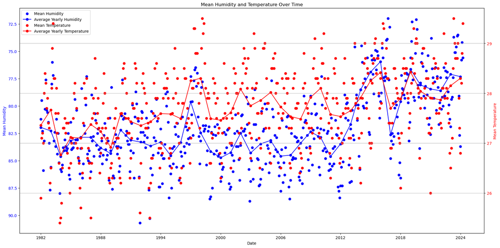

```python
# Humidity and Mean Temperature over Time
# Create the plot
fig, ax1 = plt.subplots(figsize=(18, 9))

# Plot humidity
ax1.scatter(data3['timestamp'], data3['mean_rh'], color='blue', marker='o', linestyle='-', label='Mean Humidity')
ax1.set_xlabel('Date')
ax1.set_ylabel('Mean Humidity', color='blue')
ax1.tick_params(axis='y', labelcolor='blue')
ax1.invert_yaxis()

# Convert Unix timestamps to datetime objects
timestamps = np.array([datetime.fromtimestamp(ts) for ts in data3['timestamp']])
# Extract the year from each datetime object
years = np.array([ts.year for ts in timestamps])
# Group the values by year and calculate the average, as well as convert the year back to timestamp
unique_years_humidity = np.unique(years)
average_values_humidity = np.array([np.mean(data3['mean_rh'][years == year]) for year in unique_years_humidity])
for i in range(len(unique_years_humidity)):
    unique_years_humidity[i] = convert_to_timestamp3(str(unique_years_humidity[i]))
# Plot the average yearly
ax1.plot(unique_years_humidity, average_values_humidity, marker='o', linestyle='-', label='Average Yearly Humidity', color='blue')



# Create a second y-axis for the temperature
ax2 = ax1.twinx()
ax2.scatter(data4['timestamp'], data4['mean_temp'], color='red', marker='o', linestyle='-', label='Mean Temperature')
ax2.set_ylabel('Mean Temperature', color='red')
ax2.tick_params(axis='y', labelcolor='red')

# Convert Unix timestamps to datetime objects
timestamps = np.array([datetime.fromtimestamp(ts) for ts in data4['timestamp']])
# Extract the year from each datetime object
years = np.array([ts.year for ts in timestamps])
# Group the values by year and calculate the average, as well as convert the year back to timestamp
unique_years_temp = np.unique(years)
average_values_temp = np.array([np.mean(data4['mean_temp'][years == year]) for year in unique_years_temp])
for i in range(len(unique_years_temp)):
    unique_years_temp[i] = convert_to_timestamp3(str(unique_years_temp[i]))
# Plot the average yearly
ax2.plot(unique_years_temp, average_values_temp, marker='o', linestyle='-', label='Average Yearly Temperature', color='red')

# Add a title and legend
plt.title('Mean Humidity and Temperature Over Time')
fig.tight_layout()
xlabels = ('1982', '1988', '1994','2000', '2006','2012','2018','2024')
xticks = [378691200,567993600,757382400,946684800,1136073600,1325376000,1514764800,1704067200]
plt.xticks(xticks,xlabels)

# Adding legends for both plots
lines_1, labels_1 = ax1.get_legend_handles_labels()
lines_2, labels_2 = ax2.get_legend_handles_labels()
ax1.legend(lines_1 + lines_2, labels_1 + labels_2, loc='upper left')

# Show the plot
plt.grid(True)
plt.show()
```

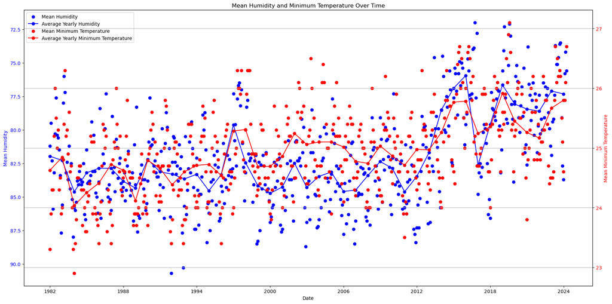

```python
# Humidity and Min Temperature over Time
# Create the plot
fig, ax1 = plt.subplots(figsize=(18, 9))

# Plot humidity
ax1.scatter(data3['timestamp'], data3['mean_rh'], color='blue', marker='o', linestyle='-', label='Mean Humidity')
ax1.set_xlabel('Date')
ax1.set_ylabel('Mean Humidity', color='blue')
ax1.tick_params(axis='y', labelcolor='blue')
ax1.invert_yaxis()
# Plot the average yearly
ax1.plot(unique_years_humidity, average_values_humidity, marker='o', linestyle='-', label='Average Yearly Humidity', color='blue')



# Create a second y-axis for the temperature
ax2 = ax1.twinx()
ax2.scatter(data4_min['timestamp'], data4_min['mean_daily_min'], color='red', marker='o', linestyle='-', label='Mean Minimum Temperature')
ax2.set_ylabel('Mean Minimum Temperature', color='red')
ax2.tick_params(axis='y', labelcolor='red')

# Convert Unix timestamps to datetime objects
timestamps = np.array([datetime.fromtimestamp(ts) for ts in data4_min['timestamp']])
# Extract the year from each datetime object
years = np.array([ts.year for ts in timestamps])
# Group the values by year and calculate the average, as well as convert the year back to timestamp
unique_years_temp_min = np.unique(years)
average_values_temp_min = np.array([np.mean(data4_min['mean_daily_min'][years == year]) for year in unique_years_temp_min])
for i in range(len(unique_years_temp_min)):
    unique_years_temp_min[i] = convert_to_timestamp3(str(unique_years_temp_min[i]))
# Plot the average yearly
ax2.plot(unique_years_temp_min, average_values_temp_min, marker='o', linestyle='-', label='Average Yearly Minimum Temperature', color='red')

# Add a title and legend
plt.title('Mean Humidity and Minimum Temperature Over Time')
fig.tight_layout()
xlabels = ('1982', '1988', '1994','2000', '2006','2012','2018','2024')
xticks = [378691200,567993600,757382400,946684800,1136073600,1325376000,1514764800,1704067200]
plt.xticks(xticks,xlabels)

# Adding legends for both plots
lines_1, labels_1 = ax1.get_legend_handles_labels()
lines_2, labels_2 = ax2.get_legend_handles_labels()
ax1.legend(lines_1 + lines_2, labels_1 + labels_2, loc='upper left')

# Show the plot
plt.grid(True)
plt.show()
```

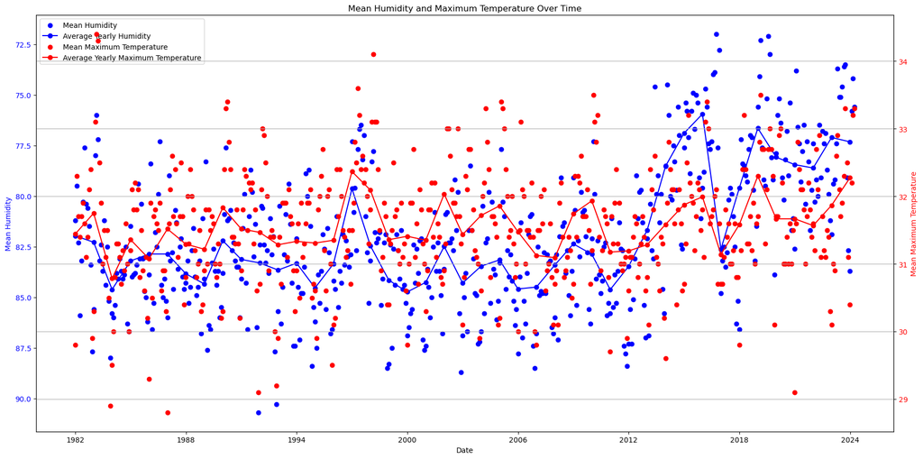

```python
# Humidity and Max Temperature over Time
# Create the plot
fig, ax1 = plt.subplots(figsize=(18, 9))

# Plot humidity
ax1.scatter(data3['timestamp'], data3['mean_rh'], color='blue', marker='o', linestyle='-', label='Mean Humidity')
ax1.set_xlabel('Date')
ax1.set_ylabel('Mean Humidity', color='blue')
ax1.tick_params(axis='y', labelcolor='blue')
ax1.invert_yaxis()
# Plot the average yearly
ax1.plot(unique_years_humidity, average_values_humidity, marker='o', linestyle='-', label='Average Yearly Humidity', color='blue')



# Create a second y-axis for the temperature
ax2 = ax1.twinx()
ax2.scatter(data4_max['timestamp'], data4_max['mean_daily_max'], color='red', marker='o', linestyle='-', label='Mean Maximum Temperature')
ax2.set_ylabel('Mean Maximum Temperature', color='red')
ax2.tick_params(axis='y', labelcolor='red')

# Convert Unix timestamps to datetime objects
timestamps = np.array([datetime.fromtimestamp(ts) for ts in data4_max['timestamp']])
# Extract the year from each datetime object
years = np.array([ts.year for ts in timestamps])
# Group the values by year and calculate the average, as well as convert the year back to timestamp
unique_years_temp_max = np.unique(years)
average_values_temp_max = np.array([np.mean(data4_max['mean_daily_max'][years == year]) for year in unique_years_temp_max])
for i in range(len(unique_years_temp_max)):
    unique_years_temp_max[i] = convert_to_timestamp3(str(unique_years_temp_max[i]))
# Plot the average yearly
ax2.plot(unique_years_temp_max, average_values_temp_max, marker='o', linestyle='-', label='Average Yearly Maximum Temperature', color='red')

# Add a title and legend
plt.title('Mean Humidity and Maximum Temperature Over Time')
fig.tight_layout()
xlabels = ('1982', '1988', '1994','2000', '2006','2012','2018','2024')
xticks = [378691200,567993600,757382400,946684800,1136073600,1325376000,1514764800,1704067200]
plt.xticks(xticks,xlabels)

# Adding legends for both plots
lines_1, labels_1 = ax1.get_legend_handles_labels()
lines_2, labels_2 = ax2.get_legend_handles_labels()
ax1.legend(lines_1 + lines_2, labels_1 + labels_2, loc='upper left')

# Show the plot
plt.grid(True)
plt.show()
```

We can see that out of the 3 charts, Minimum and Maximum Temperature seem to best indicate changes in humidity. However, all 3 charts share the same higher temperature levels compared to the line for humidity in the 2000-2012 time period, with the Maximum Temperature line following the shape of it most closely, implying that the higher humidity levels then were unaffected by higher than usual Mean and Minimum Temperatures. However, past the 2012 time period, the Maximum temperature line no longer follows the humidity line and drops below it instead, implying that the drop in humidity after 2012 is due to higher Mean and Minimum Temperatures. This raises the question as to what happened after the 2012 time period for the humidity levels to suddenly be affected by higher than useal Mean and Minimum Temperatures and why they were unaffected before.

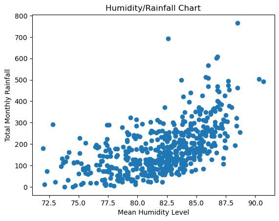

```python
# Plotting Humidity/Rainfall
# Step 1: Extract timestamps and extra variables
timestamps1 = data3['timestamp']
extra_vars1 = data3['mean_rh']
timestamps2 = data2['timestamp']
extra_vars2 = data2['total_rainfall']

# Step 2: Find the common timestamps
common_timestamps, indices1, indices2 = np.intersect1d(timestamps1, timestamps2, return_indices=True)

# Step 3: Use the indices to extract the corresponding extra variables
aligned_vars1 = extra_vars1[indices1]
aligned_vars2 = extra_vars2[indices2]

# Combine the common timestamps and the aligned extra variables into a structured array
humidity_rain = np.array(list(zip(common_timestamps, aligned_vars1, aligned_vars2)),
                  dtype=[('timestamp', 'i8'), ('mean_rh', 'f8'), ('total_rainfall', 'f8')])

# Plot table
plt.scatter(humidity_rain['mean_rh'],humidity_rain['total_rainfall'])
# Table title, etc
plt.title('Humidity/Rainfall Chart')
plt.xlabel('Mean Humidity Level')
plt.ylabel('Total Monthly Rainfall')
plt.show()
```

Humidity and Rainfall seem to correspond as well with higher rainfall leading to higher humidity and vice versa. Seems as expected as rainfall will evaporate eventually and increase the humidity in the air. However, can this be connected to the 2000-2012 and after 2012 time periods?

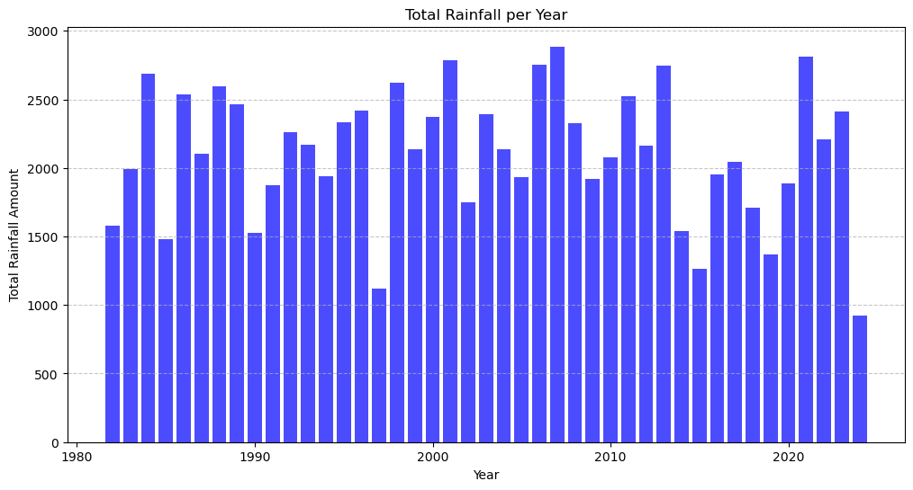

```python
# Plotting Total Rainfall per Year
# Convert Unix timestamps to datetime objects
timestamps = np.array([datetime.fromtimestamp(ts) for ts in data2['timestamp']])
total_rainfall = data2['total_rainfall']

# Extract the year from each datetime object
years = np.array([ts.year for ts in timestamps])

# Aggregate the mean relative humidity by year
unique_years_rainfall = np.unique(years)
total_rainfall_per_year = np.array([np.sum(total_rainfall[years == year]) for year in unique_years])

# Plotting the aggregated data using a bar chart
plt.figure(figsize=(12, 6))
plt.bar(unique_years, total_rainfall_per_year, color='blue', alpha=0.7)
plt.xlabel('Year')
plt.ylabel('Total Rainfall Amount')
plt.title('Total Rainfall per Year')
plt.grid(axis='y', linestyle='--', alpha=0.7)
plt.show()
```

Ignoring the last 2024 year as the data for that year is incomplete, the total rainfall per year over the years differs from year to year, though showing in variance in recent years. Next will be plotting rainfall against humidity.

[figure not shown]

```python
# Create the plot
fig, ax1 = plt.subplots(figsize=(18, 9))

# Plot humidity
ax1.scatter(data3['timestamp'], data3['mean_rh'], color='blue', marker='o', linestyle='-', label='Mean Humidity')
ax1.set_xlabel('Date')
ax1.set_ylabel('Mean Humidity', color='blue')
ax1.tick_params(axis='y', labelcolor='blue')
# No need to invert humidity axis this time
# ax1.invert_yaxis()
# Plot the average yearly
ax1.plot(unique_years_humidity, average_values_humidity, marker='o', linestyle='-', label='Average Yearly Humidity', color='blue')



# Create a second y-axis for the temperature
ax2 = ax1.twinx()
ax2.scatter(data2['timestamp'], data2['total_rainfall'], color='red', marker='o', linestyle='-', label='Rainfall Levels')
ax2.set_ylabel('Rainfall Levels', color='red')
ax2.tick_params(axis='y', labelcolor='red')
# Use previously calculated variables
average_values_rainfall = np.array([np.mean(data2['total_rainfall'][years == year]) for year in unique_years_rainfall])
for i in range(len(unique_years_rainfall)):
    unique_years_rainfall[i] = convert_to_timestamp3(str(unique_years_rainfall[i]))
# Plot the average yearly
ax2.plot(unique_years_rainfall, average_values_rainfall, marker='o', linestyle='-', label='Mean Yearly Rainfall', color='red')

# Add a title and legend
plt.title('Mean Humidity and Rainfall Levels Over Time')
fig.tight_layout()
xlabels = ('1982', '1988', '1994','2000', '2006','2012','2018','2024')
xticks = [378691200,567993600,757382400,946684800,1136073600,1325376000,1514764800,1704067200]
plt.xticks(xticks,xlabels)

# Adding legends for both plots
lines_1, labels_1 = ax1.get_legend_handles_labels()
lines_2, labels_2 = ax2.get_legend_handles_labels()
ax1.legend(lines_1 + lines_2, labels_1 + labels_2, loc='upper left')

# Show the plot
plt.grid(True)
plt.show()
```

Changes in Rainfall seem to correspond to changes in humidity up to around 2012 with the humidity line being far above rainfall, there is still a steep overall drop in humidity levels around 2012, though rainfall levels still seem to correspond with humidity to an extent.

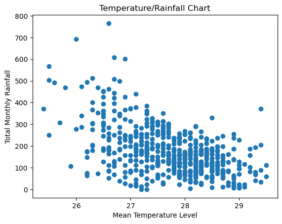

```python
# Plotting Temperature/Rainfall
# Step 1: Extract timestamps and extra variables
timestamps1 = data4['timestamp']
extra_vars1 = data4['mean_temp']
timestamps2 = data2['timestamp']
extra_vars2 = data2['total_rainfall']

# Step 2: Find the common timestamps
common_timestamps, indices1, indices2 = np.intersect1d(timestamps1, timestamps2, return_indices=True)

# Step 3: Use the indices to extract the corresponding extra variables
aligned_vars1 = extra_vars1[indices1]
aligned_vars2 = extra_vars2[indices2]

# Combine the common timestamps and the aligned extra variables into a structured array
temp_rain = np.array(list(zip(common_timestamps, aligned_vars1, aligned_vars2)),
                  dtype=[('timestamp', 'i8'), ('mean_temp', 'f8'), ('total_rainfall', 'f8')])

# Plot table
plt.scatter(temp_rain['mean_temp'],temp_rain['total_rainfall'])
# Table title, etc
plt.title('Temperature/Rainfall Chart')
plt.xlabel('Mean Temperature Level')
plt.ylabel('Total Monthly Rainfall')
plt.show()
```

Higher rainfall levels seem to correspond with lower temperatures, likely due to the evaporation of rainwater taking heat away from the surface, as well as rainclouds blocking sunlight

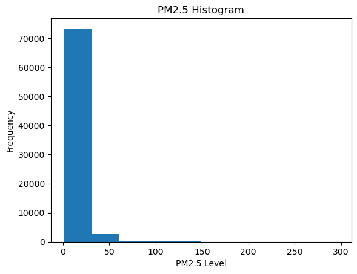

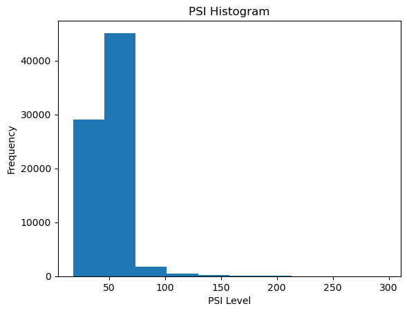

```python
# Histogram of PM2.5 and PSI
plt.hist((data['north'] + data['south'] + data['east'] + data['west'] + data['central'])/5)
plt.title('PM2.5 Histogram')
plt.xlabel('PM2.5 Level')
plt.ylabel('Frequency')
plt.show()
plt.hist((data1['north'] + data1['south'] + data1['east'] + data1['west'] + data1['central'])/5)
plt.title('PSI Histogram')
plt.xlabel('PSI Level')
plt.ylabel('Frequency')
plt.show()
## Tells me that the usual PM2.5 levels and PSI are very stable, and anything nearing 50 for PM2.5 and 100 for PSI is abnormal
```

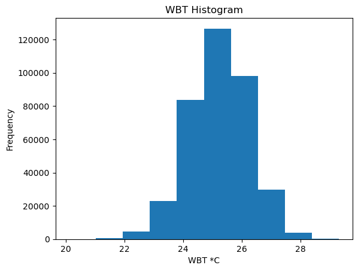

```python
# Plotting Wet Bulb Temperature Histogram
plt.hist(data5['wbt_temp'])
plt.title('WBT Histogram')
plt.xlabel('WBT *C')
plt.ylabel('Frequency')
plt.show()
```

WBT levels of 24-26 are most common and anything lower than 23 or higher than 27 is abnormal. Next is plotting distribution as a pie chart to get a more accurate display of distribution percentages.

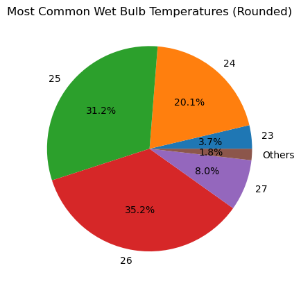

```
Total Number of Variables: 370344
```

```python
# Pie chart of WBT

# Round Wet Bulb Temperatures to the nearest integer
rounded_wbt_temp = np.round(data5['wbt_temp']).astype(int)

# Count the occurrences of each unique temperature
unique_temps, counts = np.unique(rounded_wbt_temp, return_counts=True)

# Define the main temps and initialize the dictionary to count occurrences of main and other temps
main_temps = [23, 24, 25, 26, 27]
temp_counts = {23:0,24:0,25:0,26:0,27:0,'Others':0}

# Categorize the temperatures
for temp, count in zip(unique_temps, counts):
    if temp in main_temps:
        temp_counts[temp] += count
    else:
        temp_counts['Others'] += count

# Plotting the data as a pie chart
plt.pie(temp_counts.values(), labels=temp_counts.keys(), autopct='%1.1f%%')
plt.title('Most Common Wet Bulb Temperatures (Rounded)')
plt.show()
print('Total Number of Variables: ' + str(len(rounded_wbt_temp)))
```

As we can see from the pie chart, the most common temperatures are 26,25 followed by 24 degrees celcius (rounded). 23C has a 3.7% chance of occuring and 27C has a 8% chance. Anything higher or lower is an outlier with a 1.8% chance of occuring. This is derived from a total of 370344 records of data.

As a conclusion, Singapore is rapidly becoming a drier and warmer country as time progresses. Rainfall levels are also seeing more variance in recent years. It is recommended to prepare for such eventualities in the future. Luckily WBT levels as well as air pollution levels typically remain constant and within a safe range, though we should still prepare for any anomalies.

For those curious why there is a sudden drop in humidity after 2012:

With increase in temperature, the amount of water vapour in the air is expected to increase. This is because of the Clausius-Clapeyron (CC) equation, which suggests that the air can generally hold around 7% more water vapour for every 1 oC increase in air temperature. Therefore, under global warming, for the relative humidity to be constant the water vapour content in the air should increase at the same rate i.e. 7% increase for every 1oC increase in air temperature.

However, Singapore’s observation records show a decreasing trend in relative humidity. The reasons for this are: (1) large part of water vapour in the air over land comes from the seas surrounding Singapore, and (2) the land surface has been warming at a faster rate than the surrounding seas. Hence, the moisture from the surrounding seas is not enough to increase the water vapour over land at the CC rate, leading to a decreasing trend in RH.

src: https://www.mss-int.sg/docs/default-source/v3_reports/v3-sr-chap-05.pdf

Unfortunately there are no records of sea surface temperature in beta.data.gov.